# Modelling spatial spread I - Exercises

Andrea Parisi

## **Exercise 1**

*Increase the number of patches and observe how the infection curves will tend to overlap when such number becomes large. Can you explain why?*

We start from 16 patches, then we increase to 50, 300 and 1000.

```r
patches <- c(16,50,300,1000)
NN <- list()
output <- list()
for (jj in 1:4)  {
    NN[[jj]] <- rep(10000, patches[jj])
    rho <- randomContactMatrix(patches[jj])
    start.I0 <- rep(0, patches[jj])
    start.I0[1] <- 10
    start.S0 <- NN[[jj]]-start.I0
    xstart <- c( start.S0, start.I0 )
    params <- list(patches[jj], mu, gamma, beta, rho, NN[[jj]])

    res <- deSolve::ode( xstart, times, sir.model, params, method=deSolve::rk4 )

    output[[jj]] <- data.frame( res )
}
```

Each patch will average out difference between influx from other patches: as the number of patches increases, all patches will see their influx converge towards a common average value.

```r
for (jj in 1:4)  {
    showOutput(output[[jj]], patches[jj], NN[[jj]])
}
```

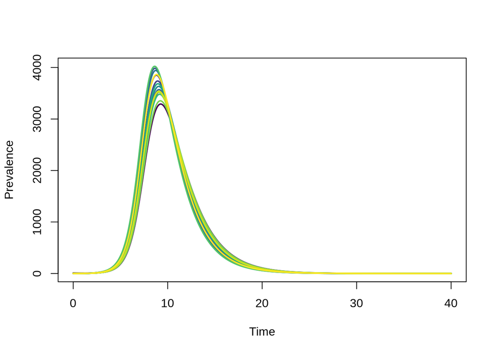

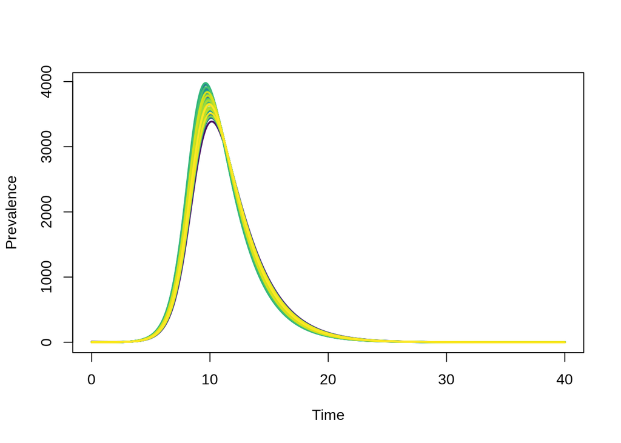

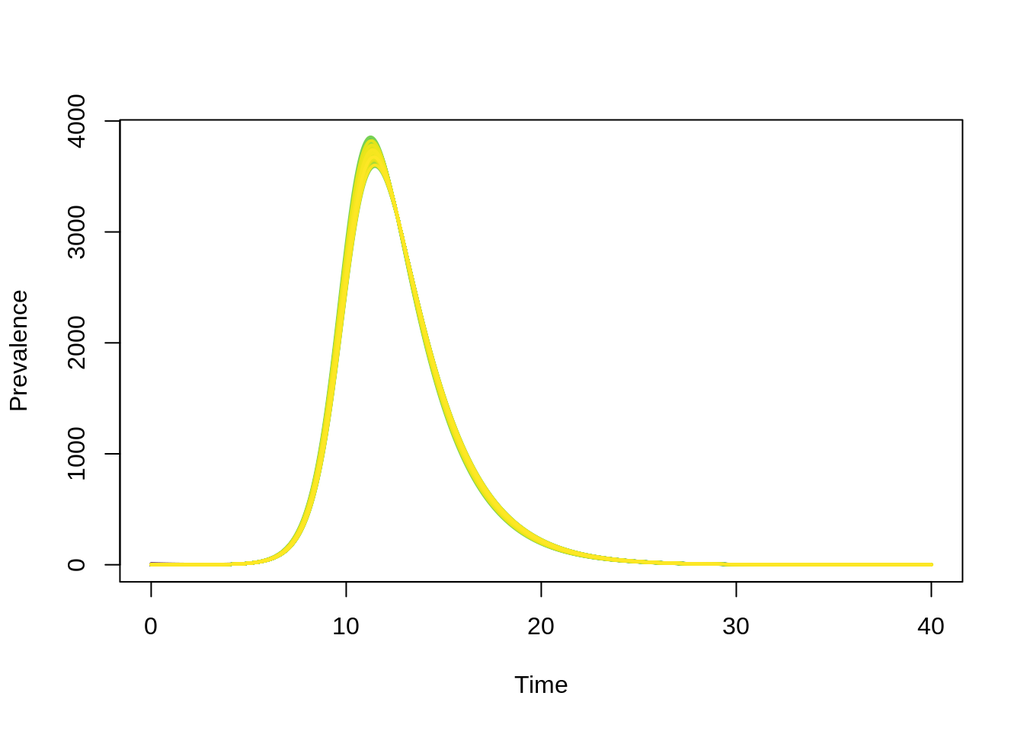

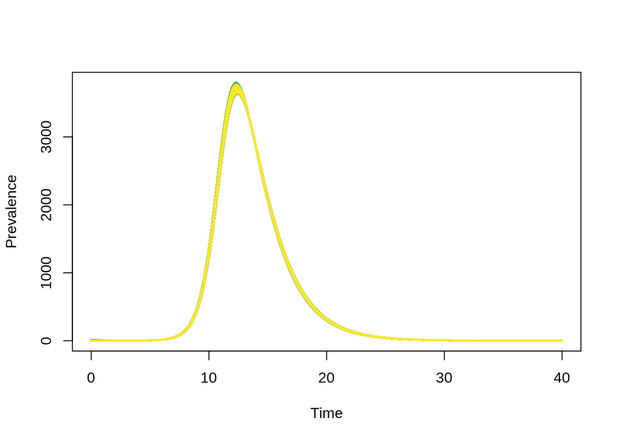

# **Exercise 2**

*Increase or decrease the population size and the initial number of infectives of each patch by the same amount. What happens to the infection curves? Why?*

```r
sizes <- c(10000, 300000, 10000000)
NN <- list()
output <- list()
side <- 4
patches <- 16
rho <- randomContactMatrix(patches)
for (jj in 1:3)  {
    NN[[jj]] <- rep(sizes[jj], patches)

    start.I0 <- rep(0, patches)
    start.I0[1] <- 10
    start.S0 <- NN[[jj]]-start.I0
    xstart <- c( start.S0, start.I0 )
    params <- list(patches, mu, gamma, beta, rho, NN[[jj]])

    res <- deSolve::ode( xstart, times, sir.model, params, method=deSolve::rk4 )
    output[[jj]] <- data.frame( res )
}

for (jj in 1:3)  {
    showOutput(output[[jj]], patches, NN[[jj]])
}
```

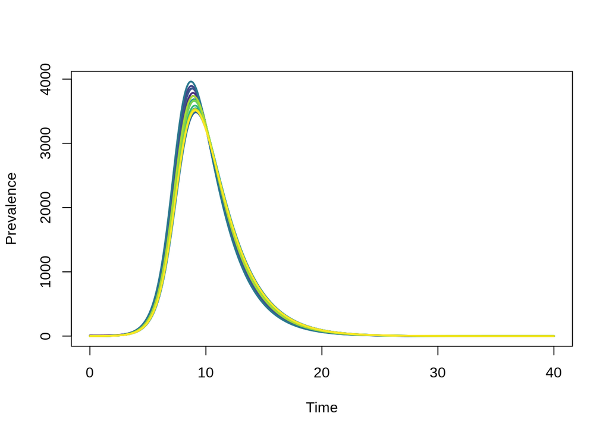

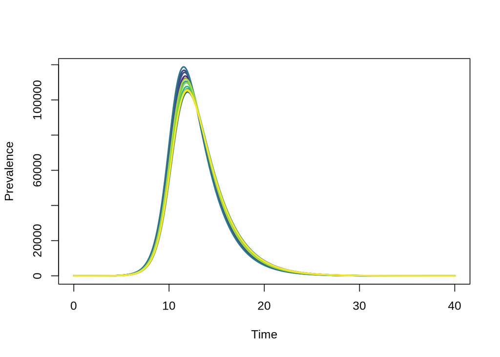

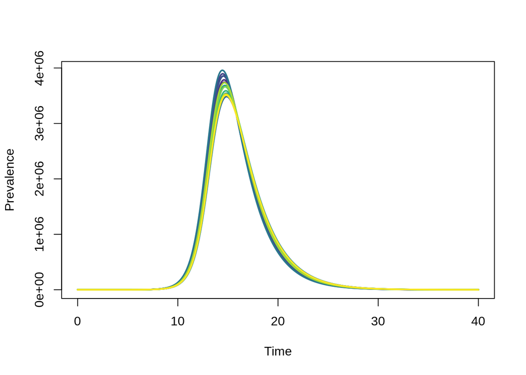

Increasing the population size produces identical curve, shifted due to the initial condition. Since the 10 initial infective represent an decreasing fraction of the population, the bigger the population size, the longer it will take for the disease to spread significantly, resulting in a shift to the right of the epidemic curve.

Of course…

```r
sizes <- c(10000, 300000, 10000000)
NN <- list()
output <- list()
side <- 4
patches <- 16
rho <- randomContactMatrix(patches)
for (jj in 1:3)  {
    NN[[jj]] <- rep(sizes[jj], patches)

    start.I0 <- rep(0, patches)
    start.I0[1] <- 10*(sizes[jj]/10000)
    start.S0 <- NN[[jj]]-start.I0
    xstart <- c( start.S0, start.I0 )
    params <- list(patches, mu, gamma, beta, rho, NN[[jj]])

    res <- deSolve::ode( xstart, times, sir.model, params, method=deSolve::rk4 )
    output[[jj]] <- data.frame( res )
}

for (jj in 1:3)  {
    showOutput(output[[jj]], patches, NN[[jj]])
}
```

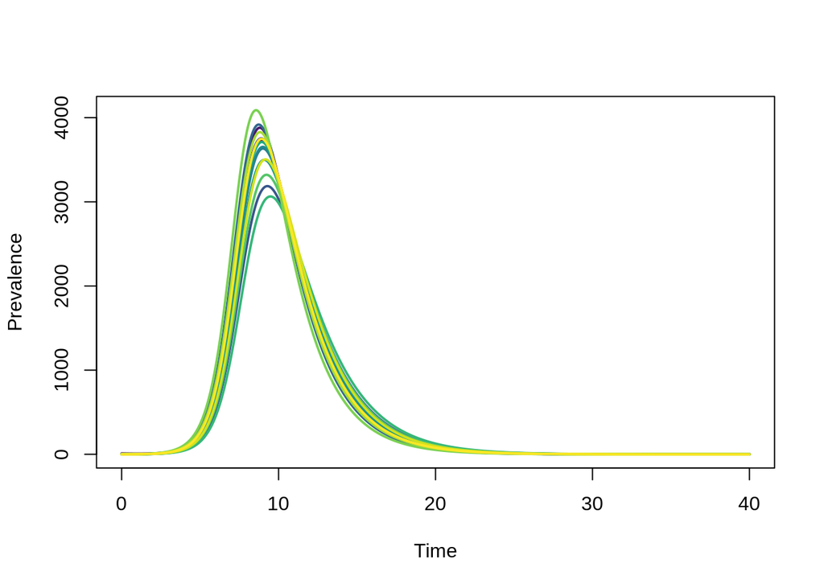

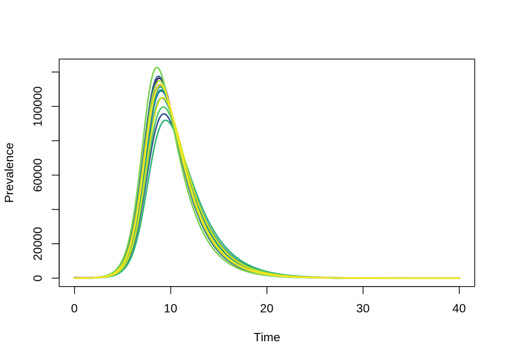

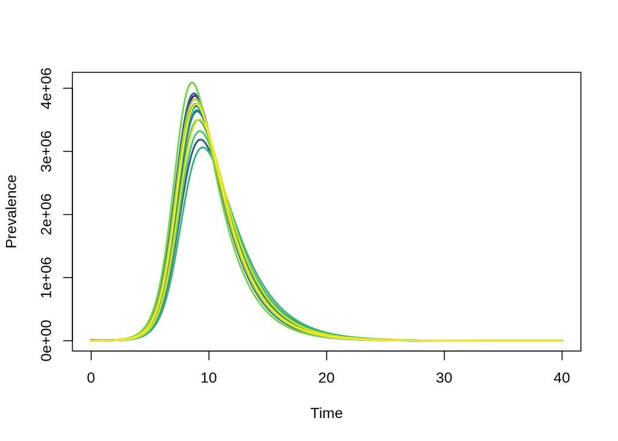

… if the initial condition is increased proportionally to the population size, the output is identical since these are continuous model and the contact matrix represents population fractions.

## **Exercise 3**

This is the original nearest-neighbours matrix

```r
patches <- 16
NN <- rep(10000, patches)
start.I0 <- rep(0, patches)
start.I0[1] <- 10
start.S0 <- NN-start.I0
xstart <- c( start.S0, start.I0 )
rho <- zeros(patches) # Generates a patches x patches matrix of zeros
for (dst in 1:patches)  {
    for (src in 1:patches)  {
        if (dst == src+side || dst == src-side ||
                   dst == src+1 || dst == src-1)  {
            rho[dst,src] <- 0.01
        }
    }
}
for (jj in 1:patches)  {
    rho[jj,jj] = 1-sum(rho[,jj])
}
params <- list(patches, mu, gamma, beta, rho, NN)
res <- deSolve::ode( xstart, times, sir.model, params, method=deSolve::rk4 )
output1 <- data.frame( res )
```

This is a contact matrix with additional tranmission to second nearest neighbours

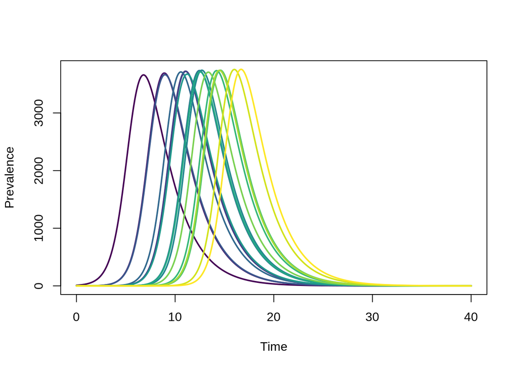

```r
patches <- 16
NN <- rep(10000, patches)
rho <- zeros(patches) # Generates a patches x patches matrix of zeros
for (dst in 1:patches)  {
    for (src in 1:patches)  {
        if (dst == src+side || dst == src-side ||
                   dst == src+1 || dst == src-1)  {
            rho[dst,src] <- 0.01
        } else if (dst == src+side-1 || dst == src-side-1 ||
                   dst == src+side+1 || dst == src-side+1)  {
            rho[dst,src] <- 0.005
        }
    }
}
for (jj in 1:patches)  {
    rho[jj,jj] = 1-sum(rho[,jj])
}
params <- list(patches, mu, gamma, beta, rho, NN)
res <- deSolve::ode( xstart, times, sir.model, params, method=deSolve::rk4 )
output2 <- data.frame( res )

showOutput(output1, patches, NN)
```

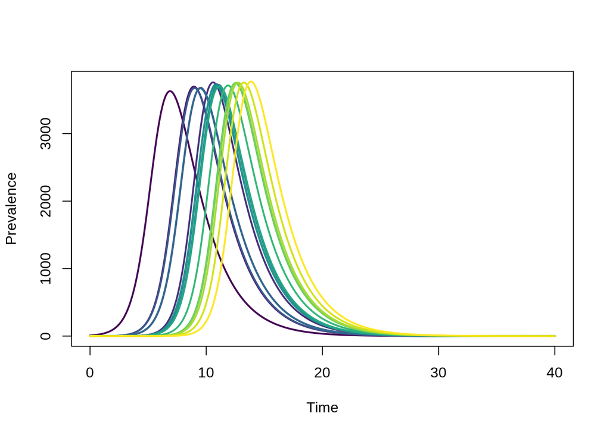

```r
showOutput(output2, patches, NN)
```

Increasing the coupling between counties makes outbreaks in far countries occur earlier.

## **Exercise 4**

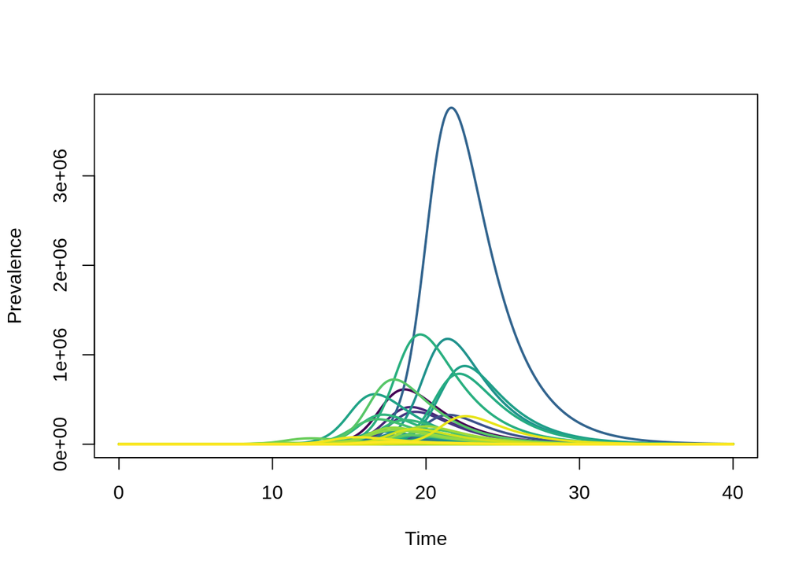

```r
NN <- counties.wsg84$pop
beta <- 1.66
times <- seq( from = 0, to = 40, by = 0.05)

rho <- build.contact.matrix( counties.wsg84, comm, "Total", 34.0 )
patches <- nrow(rho)

# Find counties 'Modoc' and 'Los Angeles'
modoc <- which(counties.wsg84$NAME == "Modoc")
start.I0 <- rep(0, patches)
start.I0[modoc] <- 10
start.S0 <- NN-start.I0
xstart <- c( start.S0, start.I0 )
params <- list(patches, mu, gamma, beta, rho, NN)

res <- deSolve::ode( xstart, times, sir.model, params, method=deSolve::rk4 )

output <- data.frame( res )
showOutput(output, patches, NN)
```

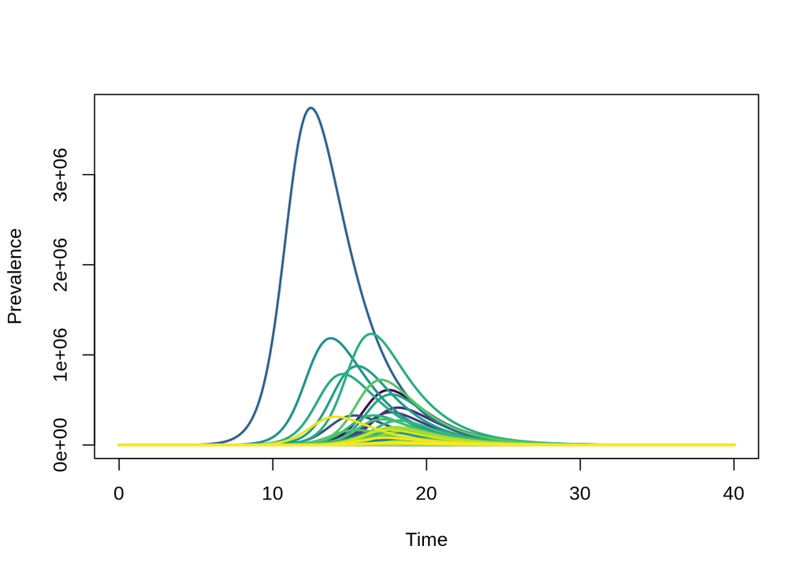

```r
losangeles <- which(counties.wsg84$NAME == "Los Angeles")
start.I0 <- rep(0, patches)
start.I0[losangeles] <- 10
start.S0 <- NN-start.I0
xstart <- c( start.S0, start.I0 )
params <- list(patches, mu, gamma, beta, rho, NN)

res <- deSolve::ode( xstart, times, sir.model, params, method=deSolve::rk4 )

output <- data.frame( res )
showOutput(output, patches, NN)
```

Los Angeles has higher connections than the Modoc county, thus an initial infective in Los Angeles would cause a faster epidemic throughout California.